# IMT574_Problem_Set_6

```python
import IPython
print( "IPython version:      %6.6s (need at least 1.0)" % IPython.__version__)

# Numpy is a library for working with arrays and matrices
import numpy as np
print( "Numpy version:        %6.6s (need at least 1.7.1)" % np.__version__)

# SciPy implements many different numerical algorithms
import scipy as sp
print( "SciPy version:        %6.6s (need at least 0.12.0)" % sp.__version__)

# Pandas makes working with data tables easier
import pandas as pd
print( "Pandas version:       %6.6s (need at least 0.11.0)" % pd.__version__)

# Module for plotting

import matplotlib.colors as mltcolors

import matplotlib.pyplot as plt

from pylab import rcParams

import matplotlib.colors

from sklearn.neighbors import KNeighborsClassifier

import warnings
warnings.filterwarnings('ignore')
```

```
IPython version:       7.6.1 (need at least 1.0)
Numpy version:        1.16.4 (need at least 1.7.1)
SciPy version:         1.2.1 (need at least 0.12.0)
Pandas version:       0.24.2 (need at least 0.11.0)
```

**1 Explore and clean the data**

*1.First, let's load data and take a closer look at it.1. Browse the WVS documentation and make sure you are familiar with coding of the variable V23.Note: you also have to consult the codebook to understand all the missings and how to remove those.*

*2. Load the data. Remove all the missing observations of V23. I mean all the missings, including the valid numeric codes that denote missing/invalid answers.*

```python
#reading the data
wvs_df= pd.read_csv('wvs.csv',sep='\t')
#checking the shape
wvs_df.shape
```

```
(90350, 328)
```

```python
wvs_df.head(5)
```

|  | V2 | V4 | V5 | V6 | V7 | V8 | V9 | V10 | V11 | V12 | ... | MN_228S8 | MN_229A | MN_230A | MN_233A | MN_237B1 | MN_249A1 | MN_249A3 | I_RELIGBEL | I_NORM1 | I_VOICE1 |
| --- | --- | --- | --- | --- | --- | --- | --- | --- | --- | --- | --- | --- | --- | --- | --- | --- | --- | --- | --- | --- | --- |
| 0 | 12 | 1 | 1 | 1 | -2 | 1 | 1 | 2 | 1 | 1 | ... | 3 | -3 | -3 | -3 | -3 | 1 | 1 | 0.0 | 1.0 | 0.00 |
| 1 | 12 | 1 | 2 | 3 | 4 | 2 | 2 | 2 | 2 | 2 | ... | 3 | -3 | -3 | -3 | -3 | 2 | -1 | 0.0 | 1.0 | 0.66 |
| 2 | 12 | 1 | 3 | 2 | 4 | 2 | 1 | 2 | 2 | 2 | ... | 4 | 1 | 1 | 2 | -3 | 1 | 1 | 0.0 | 1.0 | 0.33 |
| 3 | 12 | 1 | 1 | 3 | 4 | 3 | 1 | 2 | 1 | 2 | ... | 2 | 2 | 1 | 2 | -3 | 1 | 2 | 0.0 | 1.0 | 0.00 |
| 4 | 12 | 1 | 1 | 1 | 2 | 1 | 1 | 1 | 3 | 2 | ... | 2 | 2 | 1 | 2 | -3 | 1 | 2 | 0.0 | 1.0 | 0.66 |

5 rows × 328 columns

```python
wvs_df["V23"].head(10)
```

```
0    8
1    5
2    4
3    8
4    8
5    7
6    7
7    5
8    6
9    5
Name: V23, dtype: int64
```

```python
#totalnull values
print("Total number of null values:", sum(pd.isnull(wvs_df["V23"])))
```

```
Total number of null values: 0
```

There are no null values as we observe for V23 feature in the data set. However we still need to handle the valid numeric codes that suggest invalid answers. These codes are ranging from -5 to -1 and RU.

```python
a = wvs_df.apply(lambda x: True if x['V23'] < 0 else False , axis=1)

# Count number of True in series
num_rows = len(a[a == True].index)

print('Number of rows with invalid negative codes : ', num_rows)
```

```
Number of rows with invalid negative codes :  579
```

There are 579 values which could be from -5 to -1. These rows need to be cleaned.

```python
a = wvs_df.apply(lambda x: True if x['V23'] == "RU" else False , axis=1)

# Count number of True in series
num_rows = len(a[a == True].index)

print('Number of rows with an inappropriate response : ', num_rows)
```

```
Number of rows with an inappropriate response :  0
```

There are no rows with an inappropriate response.

```python
#1.3 Removing missing values and invalid codes. We will only take rows that have positive values.

#a) selecting only those rows having V23 > 0

data_clean = wvs_df[(wvs_df["V23"]>0)]
data_clean.shape
```

```
(89771, 328)
```

We have handled all the invalid coded rows and cleaned the data to include only positive coded ot appropriate responses.

```python
a = data_clean.apply(lambda x: True if x['V23'] > 0 else False , axis=1)

# Count number of True in series
num_rows = len(a[a == True].index)

print('Number of rows in the cleaned data frame : ', num_rows)
```

```
Number of rows in the cleaned data frame :  89771
```

*3. Now make a table (or a plot) of different answers. What is the mean satisfaction level on this planet? How large a proportion of people are at 6 or more satisfied?(Note: without knowing more about how the sample was created, we should not talk about the planet. We should refer to "respondents" instead.)*

```python
data_clean["V23"].mean()
```

```
6.8290316471911865
```

```python
print('The mean satisfaction level recorded for the respondents is : ',data_clean["V23"].mean())
```

```
The mean satisfaction level recorded for the respondents is :  6.8290316471911865
```

```python
GroupByDf = data_clean.groupby(['V23']).count()
GroupByDf['count']= GroupByDf['V2']
GroupByDf
```

| V23 | V2 | V4 | V5 | V6 | V7 | V8 | V9 | V10 | V11 | V12 | ... | MN_229A | MN_230A | MN_233A | MN_237B1 | MN_249A1 | MN_249A3 | I_RELIGBEL | I_NORM1 | I_VOICE1 | count |
| --- | --- | --- | --- | --- | --- | --- | --- | --- | --- | --- | --- | --- | --- | --- | --- | --- | --- | --- | --- | --- | --- |
| 1 | 2828 | 2828 | 2828 | 2828 | 2828 | 2828 | 2828 | 2828 | 2828 | 2828 | ... | 2828 | 2828 | 2828 | 2828 | 2828 | 2828 | 2486 | 2753 | 2653 | 2828 |
| 2 | 1985 | 1985 | 1985 | 1985 | 1985 | 1985 | 1985 | 1985 | 1985 | 1985 | ... | 1985 | 1985 | 1985 | 1985 | 1985 | 1985 | 1828 | 1937 | 1881 | 1985 |
| 3 | 3463 | 3463 | 3463 | 3463 | 3463 | 3463 | 3463 | 3463 | 3463 | 3463 | ... | 3463 | 3463 | 3463 | 3463 | 3463 | 3463 | 3153 | 3372 | 3320 | 3463 |
| 4 | 4600 | 4600 | 4600 | 4600 | 4600 | 4600 | 4600 | 4600 | 4600 | 4600 | ... | 4600 | 4600 | 4600 | 4600 | 4600 | 4600 | 4368 | 4522 | 4392 | 4600 |
| 5 | 11331 | 11331 | 11331 | 11331 | 11331 | 11331 | 11331 | 11331 | 11331 | 11331 | ... | 11331 | 11331 | 11331 | 11331 | 11331 | 11331 | 10713 | 11061 | 10696 | 11331 |
| 6 | 10666 | 10666 | 10666 | 10666 | 10666 | 10666 | 10666 | 10666 | 10666 | 10666 | ... | 10666 | 10666 | 10666 | 10666 | 10666 | 10666 | 10141 | 10468 | 10156 | 10666 |
| 7 | 15493 | 15493 | 15493 | 15493 | 15493 | 15493 | 15493 | 15493 | 15493 | 15493 | ... | 15493 | 15493 | 15493 | 15493 | 15493 | 15493 | 14766 | 15277 | 14834 | 15493 |
| 8 | 18213 | 18213 | 18213 | 18213 | 18213 | 18213 | 18213 | 18213 | 18213 | 18213 | ... | 18213 | 18213 | 18213 | 18213 | 18213 | 18213 | 17402 | 17947 | 17494 | 18213 |
| 9 | 9264 | 9264 | 9264 | 9264 | 9264 | 9264 | 9264 | 9264 | 9264 | 9264 | ... | 9264 | 9264 | 9264 | 9264 | 9264 | 9264 | 8894 | 9142 | 8899 | 9264 |
| 10 | 11928 | 11928 | 11928 | 11928 | 11928 | 11928 | 11928 | 11928 | 11928 | 11928 | ... | 11928 | 11928 | 11928 | 11928 | 11928 | 11928 | 11516 | 11728 | 11191 | 11928 |

10 rows × 328 columns

```python
GroupByDf = data_clean.groupby(['V23']).count()
GroupByDf
```

| V23 | V2 | V4 | V5 | V6 | V7 | V8 | V9 | V10 | V11 | V12 | ... | MN_228S8 | MN_229A | MN_230A | MN_233A | MN_237B1 | MN_249A1 | MN_249A3 | I_RELIGBEL | I_NORM1 | I_VOICE1 |
| --- | --- | --- | --- | --- | --- | --- | --- | --- | --- | --- | --- | --- | --- | --- | --- | --- | --- | --- | --- | --- | --- |
| 1 | 2828 | 2828 | 2828 | 2828 | 2828 | 2828 | 2828 | 2828 | 2828 | 2828 | ... | 2828 | 2828 | 2828 | 2828 | 2828 | 2828 | 2828 | 2486 | 2753 | 2653 |
| 2 | 1985 | 1985 | 1985 | 1985 | 1985 | 1985 | 1985 | 1985 | 1985 | 1985 | ... | 1985 | 1985 | 1985 | 1985 | 1985 | 1985 | 1985 | 1828 | 1937 | 1881 |
| 3 | 3463 | 3463 | 3463 | 3463 | 3463 | 3463 | 3463 | 3463 | 3463 | 3463 | ... | 3463 | 3463 | 3463 | 3463 | 3463 | 3463 | 3463 | 3153 | 3372 | 3320 |
| 4 | 4600 | 4600 | 4600 | 4600 | 4600 | 4600 | 4600 | 4600 | 4600 | 4600 | ... | 4600 | 4600 | 4600 | 4600 | 4600 | 4600 | 4600 | 4368 | 4522 | 4392 |
| 5 | 11331 | 11331 | 11331 | 11331 | 11331 | 11331 | 11331 | 11331 | 11331 | 11331 | ... | 11331 | 11331 | 11331 | 11331 | 11331 | 11331 | 11331 | 10713 | 11061 | 10696 |
| 6 | 10666 | 10666 | 10666 | 10666 | 10666 | 10666 | 10666 | 10666 | 10666 | 10666 | ... | 10666 | 10666 | 10666 | 10666 | 10666 | 10666 | 10666 | 10141 | 10468 | 10156 |
| 7 | 15493 | 15493 | 15493 | 15493 | 15493 | 15493 | 15493 | 15493 | 15493 | 15493 | ... | 15493 | 15493 | 15493 | 15493 | 15493 | 15493 | 15493 | 14766 | 15277 | 14834 |
| 8 | 18213 | 18213 | 18213 | 18213 | 18213 | 18213 | 18213 | 18213 | 18213 | 18213 | ... | 18213 | 18213 | 18213 | 18213 | 18213 | 18213 | 18213 | 17402 | 17947 | 17494 |
| 9 | 9264 | 9264 | 9264 | 9264 | 9264 | 9264 | 9264 | 9264 | 9264 | 9264 | ... | 9264 | 9264 | 9264 | 9264 | 9264 | 9264 | 9264 | 8894 | 9142 | 8899 |
| 10 | 11928 | 11928 | 11928 | 11928 | 11928 | 11928 | 11928 | 11928 | 11928 | 11928 | ... | 11928 | 11928 | 11928 | 11928 | 11928 | 11928 | 11928 | 11516 | 11728 | 11191 |

10 rows × 327 columns

We would display the summary percentages of each of the V23 values which would tell what V23 rating how many resonses.

```python
GroupByDf = data_clean.groupby(['V23']).count()
GroupByDf['count']= GroupByDf['V2']

GroupByDf1= GroupByDf[['count']]
Total_Responses=data_clean.shape[0]
GroupByDf1['Percentage'] = GroupByDf1.apply(lambda x: 100 * x /Total_Responses)
GroupByDf1
```

| V23 | count | Percentage |
| --- | --- | --- |
| 1 | 2828 | 3.150238 |
| 2 | 1985 | 2.211182 |
| 3 | 3463 | 3.857593 |
| 4 | 4600 | 5.124149 |
| 5 | 11331 | 12.622116 |
| 6 | 10666 | 11.881343 |
| 7 | 15493 | 17.258357 |
| 8 | 18213 | 20.288289 |
| 9 | 9264 | 10.319591 |
| 10 | 11928 | 13.287142 |

In order to understand the proportion of the responses let us group the responses based whether the satisfaction rating was less than 6 or more than and equal to 6

```python
m1 = (data_clean['V23'] >=6)
GroupByDf2 =data_clean.groupby(np.where(m1, 'Greater than or equal to 6', 'Less than 6'))['V2'].count()
GroupByDf2
```

```
Greater than or equal to 6    65564
Less than 6                   24207
Name: V2, dtype: int64
```

Summary of the Proportion of the repsonses:

```python
print('Percentage of responses with satisfaction greater than or equal to 6 :',(GroupByDf2[0]/Total_Responses)*100,'% ' )
print('Percentage of responses with satisfaction less than 6 :',(GroupByDf2[1]/Total_Responses)*100,'% ')
```

```
Percentage of responses with satisfaction greater than or equal to 6 : 73.03472168072095 %
Percentage of responses with satisfaction less than 6 : 26.965278319279058 %
```

**Q2- Create the Design Matrix**

*Q2.1- Create your outcome variable y out of life satisfaction V23 (remove missings!)*

```python
data_clean.columns
```

```
Index(['V2', 'V4', 'V5', 'V6', 'V7', 'V8', 'V9', 'V10', 'V11', 'V12',
       ...
       'MN_228S8', 'MN_229A', 'MN_230A', 'MN_233A', 'MN_237B1', 'MN_249A1',
       'MN_249A3', 'I_RELIGBEL', 'I_NORM1', 'I_VOICE1'],
      dtype='object', length=328)
```

```python
data_clean.shape
```

```
(89771, 328)
```

*Q2.1- Create your outcome variable y out of life satisfaction V23 (remove missings!)*

```python
#X_initial = data_variables.drop(['V23'],axis = 1)
```

```python
missingvalues = data_clean.where(data_clean < 0).count().sort_values().head(160)
```

```python
req_columns = missingvalues.index.tolist()
```

```python
reqcol1_df = data_clean.copy()

reqcol1_df = reqcol1_df[req_columns]
for col in req_columns:
    reqcol1_df = reqcol1_df[reqcol1_df[col] >=0]
```

```python
reqcol1_df.shape
```

```
(37171, 160)
```

```python
#We would drop the na value rows
reqqcol1_df = reqcol1_df.dropna(axis=1)
```

```python
reqqcol1_df.shape
```

```
(37171, 160)
```

```python
#We would wrie a functio to convert categorical
```

```python
reqqcol1_df.columns
```

```
Index(['V2', 'I_RELIGBEL', 'V258A', 'I_NORM1', 'V23', 'I_VOICE1', 'V22', 'V13',
       'V14', 'V16',
       ...
       'V65', 'V54', 'V222', 'V145', 'V152', 'V63', 'Y002', 'V136', 'V97',
       'V119'],
      dtype='object', length=160)
```

We can find that the following columns are categorical, so we would form dummy columns:

V1,V2,V3,V61,V62,V63,V64,V65,V80

```python
#Only some of these variables would be in the variables we had selected, we are finding them.
cols_list = ['V1','V2','V3','V61','V62','V63','V64','V65','V80']
cols_for_dummy = []
for col in cols_list:
    if col in reqqcol1_df:
        cols_for_dummy.append(col)

cols_for_dummy
```

```
['V2', 'V62', 'V63', 'V64', 'V65', 'V80']
```

```python
#We are changing V61 into dummy
reqqcol1_df = pd.get_dummies(reqqcol1_df, columns = ['V2', 'V62', 'V63', 'V64', 'V65', 'V80'])
```

```python
reqqcol1_df.shape
```

```
(37171, 223)
```

```python
reqqcol1_df.columns.tolist()
```

```
['I_RELIGBEL',
 'V258A',
 'I_NORM1',
 'V23',
 'I_VOICE1',
 'V22',
 'V13',
 'V14',
 'V16',
 'V18',
 'V17',
 'V12',
 'V44',
 'V20',
 'V15',
 'V21',
 'V19',
 'V240',
 'V242',
 'V57',
 'V11',
 'V4',
 'V5',
 'V59',
 'V10',
 'V25',
 'V248',
 'V26',
 'V84',
 'V27',
 'V6',
 'V32',
 'V30',
 'V34',
 'V33',
 'V225',
 'V200',
 'V55',
 'V9',
 'V188',
```

[output cut: 168 more lines]

```
 'V63_3',
 'V63_4',
 'V64_1',
 'V64_2',
 'V64_3',
 'V64_4',
 'V65_1',
 'V65_2',
 'V65_3',
 'V65_4',
 'V80_1',
 'V80_2',
 'V80_3',
 'V80_4',
 'V80_5']
```

```python
#We would delete one dummy columns for each of these variables
del reqqcol1_df['V2_12']
del reqqcol1_df['V62_1']
del reqqcol1_df['V63_1']
del reqqcol1_df['V64_1']
del reqqcol1_df['V65_1']
del reqqcol1_df['V80_2']
```

```python
reqqcol1_df.shape
```

```
(37171, 217)
```

We have selected the required columns, deleted the missing values, converted the categorical columns into dummy variables and removed one dummy column rom every category.

We would nor create a design matrix and Y

```python
Design_Matrix = reqqcol1_df.loc[:,reqqcol1_df.columns != 'V23']
```

```python
Y = pd.DataFrame(reqqcol1_df['V23'])
```

```python
Design_Matrix.shape
```

```
(37171, 216)
```

```python
Y.shape
```

```
(37171, 1)
```

**Q3- Condition numbers**

*Q3.1 Compute the condition number of your output matrix in such a manner. The output may look something like:*

```python
columns = Design_Matrix.columns.tolist()
```

```python
temp_matrix = pd.DataFrame() #creating a temporary matrix for adding variables
condition_number_df = pd.DataFrame() #creating a matrix for finding condition number after adding every variable
for col in columns:
    temp_matrix[col] = Design_Matrix[col]
    cond_num = np.linalg.cond(temp_matrix)
    num_columns = len(temp_matrix.columns)
    #condition_number_df['variable':col, 'number_of_columns':num_columns,'condition_number':cond_num]
    condition_number_df = condition_number_df.append({'variable':col,'condition_number':cond_num,'number_of_columns':num_columns},ignore_index = True)
```

```python
condition_number_df
```

|  | condition_number | number_of_columns | variable |
| --- | --- | --- | --- |
| 0 | 1.000000 | 1.0 | I_RELIGBEL |
| 1 | 2.528983 | 2.0 | V258A |
| 2 | 2.764215 | 3.0 | I_NORM1 |
| 3 | 3.855253 | 4.0 | I_VOICE1 |
| 4 | 6.584583 | 5.0 | V22 |
| 5 | 8.092950 | 6.0 | V13 |
| 6 | 9.090253 | 7.0 | V14 |
| 7 | 10.009185 | 8.0 | V16 |
| 8 | 11.219817 | 9.0 | V18 |
| 9 | 12.363279 | 10.0 | V17 |
| 10 | 13.234825 | 11.0 | V12 |
| 11 | 14.467072 | 12.0 | V44 |
| 12 | 15.429653 | 13.0 | V20 |
| 13 | 16.471913 | 14.0 | V15 |
| 14 | 17.265660 | 15.0 | V21 |
| 15 | 17.998541 | 16.0 | V19 |
| 16 | 18.649767 | 17.0 | V240 |
| 17 | 140.078661 | 18.0 | V242 |
| 18 | 140.310363 | 19.0 | V57 |
| 19 | 140.455281 | 20.0 | V11 |
| 20 | 141.047620 | 21.0 | V4 |
| 21 | 141.290301 | 22.0 | V5 |
| 22 | 142.702972 | 23.0 | V59 |
| 23 | 143.101466 | 24.0 | V10 |
| 24 | 143.467035 | 25.0 | V25 |
| 25 | 144.672939 | 26.0 | V248 |
| 26 | 144.694296 | 27.0 | V26 |
| 27 | 145.101589 | 28.0 | V84 |
| 28 | 145.128661 | 29.0 | V27 |
| 29 | 145.285270 | 30.0 | V6 |
| ... | ... | ... | ... |
| 186 | 907.070979 | 187.0 | V2_646 |
| 187 | 947.898115 | 188.0 | V2_702 |
| 188 | 978.736729 | 189.0 | V2_705 |
| 189 | 1037.992597 | 190.0 | V2_710 |
| 190 | 1140.209615 | 191.0 | V2_716 |
| 191 | 1180.473025 | 192.0 | V2_752 |
| 192 | 1272.835915 | 193.0 | V2_764 |
| 193 | 1348.950262 | 194.0 | V2_780 |
| 194 | 1436.233178 | 195.0 | V2_788 |
| 195 | 1568.495712 | 196.0 | V2_792 |
| 196 | 1890.163442 | 197.0 | V2_804 |
| 197 | 3012.812182 | 198.0 | V2_840 |
| 198 | 3702.449206 | 199.0 | V2_858 |
| 199 | 4805.954763 | 200.0 | V2_887 |
| 200 | 4813.652953 | 201.0 | V62_2 |
| 201 | 4815.070296 | 202.0 | V62_3 |
| 202 | 6969.916451 | 203.0 | V62_4 |
| 203 | 6970.793145 | 204.0 | V63_2 |
| 204 | 7014.540346 | 205.0 | V63_3 |
| 205 | 40881.280031 | 206.0 | V63_4 |
| 206 | 40884.508577 | 207.0 | V64_2 |
| 207 | 40886.166306 | 208.0 | V64_3 |
| 208 | 40886.341957 | 209.0 | V64_4 |
| 209 | 40898.448290 | 210.0 | V65_2 |
| 210 | 40898.876839 | 211.0 | V65_3 |
| 211 | 40900.479166 | 212.0 | V65_4 |
| 212 | 40904.288123 | 213.0 | V80_1 |
| 213 | 40904.661892 | 214.0 | V80_3 |
| 214 | 40907.074742 | 215.0 | V80_4 |
| 215 | 40908.008254 | 216.0 | V80_5 |

216 rows × 3 columns

We can see that the condition number was 7014.540346 till we added the column V63_3.

When we added the column V63_4, the condition n umber rose to 40881.280031.

So we would try to find the condition numbers without taking this column.

```python
Design_Matrix_copy = Design_Matrix.copy()
del Design_Matrix_copy['V63_4']
```

```python
columns = Design_Matrix_copy.columns.tolist()
```

```python
temp_matrix = pd.DataFrame()
condition_number_df = pd.DataFrame()
for col in columns:
    temp_matrix[col] = Design_Matrix[col]
    cond_num = np.linalg.cond(temp_matrix)
    num_columns = len(temp_matrix.columns)
    #condition_number_df['variable':col, 'number_of_columns':num_columns,'condition_number':cond_num]
    condition_number_df = condition_number_df.append({'variable':col,'condition_number':cond_num,'number_of_columns':num_columns},ignore_index = True)
```

```python
condition_number_df
```

|  | condition_number | number_of_columns | variable |
| --- | --- | --- | --- |
| 0 | 1.000000 | 1.0 | I_RELIGBEL |
| 1 | 2.528983 | 2.0 | V258A |
| 2 | 2.764215 | 3.0 | I_NORM1 |
| 3 | 3.855253 | 4.0 | I_VOICE1 |
| 4 | 6.584583 | 5.0 | V22 |
| 5 | 8.092950 | 6.0 | V13 |
| 6 | 9.090253 | 7.0 | V14 |
| 7 | 10.009185 | 8.0 | V16 |
| 8 | 11.219817 | 9.0 | V18 |
| 9 | 12.363279 | 10.0 | V17 |
| 10 | 13.234825 | 11.0 | V12 |
| 11 | 14.467072 | 12.0 | V44 |
| 12 | 15.429653 | 13.0 | V20 |
| 13 | 16.471913 | 14.0 | V15 |
| 14 | 17.265660 | 15.0 | V21 |
| 15 | 17.998541 | 16.0 | V19 |
| 16 | 18.649767 | 17.0 | V240 |
| 17 | 140.078661 | 18.0 | V242 |
| 18 | 140.310363 | 19.0 | V57 |
| 19 | 140.455281 | 20.0 | V11 |
| 20 | 141.047620 | 21.0 | V4 |
| 21 | 141.290301 | 22.0 | V5 |
| 22 | 142.702972 | 23.0 | V59 |
| 23 | 143.101466 | 24.0 | V10 |
| 24 | 143.467035 | 25.0 | V25 |
| 25 | 144.672939 | 26.0 | V248 |
| 26 | 144.694296 | 27.0 | V26 |
| 27 | 145.101589 | 28.0 | V84 |
| 28 | 145.128661 | 29.0 | V27 |
| 29 | 145.285270 | 30.0 | V6 |
| ... | ... | ... | ... |
| 185 | 895.218532 | 186.0 | V2_643 |
| 186 | 907.070979 | 187.0 | V2_646 |
| 187 | 947.898115 | 188.0 | V2_702 |
| 188 | 978.736729 | 189.0 | V2_705 |
| 189 | 1037.992597 | 190.0 | V2_710 |
| 190 | 1140.209615 | 191.0 | V2_716 |
| 191 | 1180.473025 | 192.0 | V2_752 |
| 192 | 1272.835915 | 193.0 | V2_764 |
| 193 | 1348.950262 | 194.0 | V2_780 |
| 194 | 1436.233178 | 195.0 | V2_788 |
| 195 | 1568.495712 | 196.0 | V2_792 |
| 196 | 1890.163442 | 197.0 | V2_804 |
| 197 | 3012.812182 | 198.0 | V2_840 |
| 198 | 3702.449206 | 199.0 | V2_858 |
| 199 | 4805.954763 | 200.0 | V2_887 |
| 200 | 4813.652953 | 201.0 | V62_2 |
| 201 | 4815.070296 | 202.0 | V62_3 |
| 202 | 6969.916451 | 203.0 | V62_4 |
| 203 | 6970.793145 | 204.0 | V63_2 |
| 204 | 7014.540346 | 205.0 | V63_3 |
| 205 | 7014.982921 | 206.0 | V64_2 |
| 206 | 7015.025662 | 207.0 | V64_3 |
| 207 | 7023.023947 | 208.0 | V64_4 |
| 208 | 7025.967453 | 209.0 | V65_2 |
| 209 | 7034.623839 | 210.0 | V65_3 |
| 210 | 7067.944101 | 211.0 | V65_4 |
| 211 | 7069.245495 | 212.0 | V80_1 |
| 212 | 7073.663048 | 213.0 | V80_3 |
| 213 | 7075.445211 | 214.0 | V80_4 |
| 214 | 7095.411485 | 215.0 | V80_5 |

215 rows × 3 columns

We can say that after we removed the column V63_4, the condition number did not increase drastically. So it is the culprit variable. We would take the Design_Matrix_copy as our design matrix as it does not have this column.

**Q4-Do Some Social Science: Before getting further, let's do a simple social science analysis. How is life satisfaction related to health (v11 ), perceived control over life (v55 ) and nancial situation (v59 )? Let's analyze association between satisfaction and just these three variables.**

*Q4.1- run a linear regression models explaining satisfaction with these three variables. Present the output table.*

We would add the y variable to the final Design Matrix to make regression easier.

```python
Design_Matrix_plusY =Design_Matrix_copy.copy()
Design_Matrix_plusY['V23'] = Y
```

```python
Design_Matrix_plusY.V23.value_counts()
```

```
8     7807
7     6583
10    5046
6     4489
5     4383
9     3931
4     1845
3     1378
1      956
2      753
Name: V23, dtype: int64
```

```python
import statsmodels.formula.api as smf

model1 = smf.ols(formula='V23 ~ V11+V55+V59', data=Design_Matrix_plusY).fit()
```

```python
model1.summary()
```

OLS Regression Results

| Dep. Variable: | V23 | R-squared: | 0.314 |
| --- | --- | --- | --- |
| Model: | OLS | Adj. R-squared: | 0.314 |
| Method: | Least Squares | F-statistic: | 5679. |
| Date: | Thu, 05 Mar 2020 | Prob (F-statistic): | 0.00 |
| Time: | 20:32:15 | Log-Likelihood: | -75316. |
| No. Observations: | 37171 | AIC: | 1.506e+05 |
| Df Residuals: | 37167 | BIC: | 1.507e+05 |
| Df Model: | 3 |  |  |
| Covariance Type: | nonrobust |  |  |

|  | coef | std err | t | P>\|t\| | [0.025 | 0.975] |
| --- | --- | --- | --- | --- | --- | --- |
| Intercept | 3.6977 | 0.049 | 76.154 | 0.000 | 3.602 | 3.793 |
| V11 | -0.3848 | 0.012 | -32.674 | 0.000 | -0.408 | -0.362 |
| V55 | 0.2616 | 0.005 | 55.487 | 0.000 | 0.252 | 0.271 |
| V59 | 0.3480 | 0.004 | 83.359 | 0.000 | 0.340 | 0.356 |

| Omnibus: | 1868.908 | Durbin-Watson: | 1.700 |
| --- | --- | --- | --- |
| Prob(Omnibus): | 0.000 | Jarque-Bera (JB): | 3359.585 |
| Skew: | -0.396 | Prob(JB): | 0.00 |
| Kurtosis: | 4.241 | Cond. No. | 51.7 |

Warnings:  
[1] Standard Errors assume that the covariance matrix of the errors is correctly specified.

*Q4.2- comment the output table in terms of relative eect size and statistical signi cance. Any surprises for you?*

The intercept is 3.6977; coefficient of V11(health) is -0.3848; the coefficient of V55(perceived control over life) is 0.2616; the coefficient of V59(financial situation) is 0.3480.

All of these models are statistically significant as their p value approaches 0.

I find it surprising the coefficient of health is negative.

*Q4.3- compute and present RMSE (just on training data). This will serve as the benchmark for the future.*

```python
from statsmodels.tools.eval_measures import rmse

ypred = model1.predict(Design_Matrix_plusY)
```

```python
rmse = rmse(Design_Matrix_plusY['V23'],ypred)
```

```python
rmse
```

```
1.8354003513240678
```

The calculated RMSE on training data = 1.8354003513240678

**Q5- Back to ML: Model: Now it is time to use all these variables to model satisfaction. Use sklearn.linear_model.LinearRegression here as this is easy to be switched with ridge and lasso, and it takes in the design matrix directly.**

*Q5.1- compute the condition number for your design matrix (just a single number, not the stepwise pro- cedure).*

```python
cond_num = np.linalg.cond(Design_Matrix_copy)
cond_num
```

```
7095.411485185639
```

*Q5.2- Split the data into training-validation chunks (80-20 or so)*

```python
from sklearn.model_selection import train_test_split

X_train, X_test, y_train, y_test = train_test_split(Design_Matrix_copy, Y, test_size=0.2)
```

*Q5.3-compute the condition number for your training design matrix (just a single number, not the stepwise procedure).*

```python
cond_num_train_design_matrix= np.linalg.cond(X_train)
cond_num_train_design_matrix
```

```
7093.742815869059
```

*Q5.4-fit a linear regression model where you describe satisfaction with the design matrix X you just created.*

```python
from sklearn.linear_model import LinearRegression
from sklearn import metrics

regressor = LinearRegression()
```

```python
#We are fittinga linear regression model
regressor.fit(X_train, y_train)
```

```
LinearRegression(copy_X=True, fit_intercept=True, n_jobs=None, normalize=False)
```

*Q5.5-predict and compute RMSE on training data*

```python
#We are finding predicted values for training data
y_pred_train = regressor.predict(X_train)
```

```python
#We are finding the RMSE on training data
rmse_train= np.sqrt(metrics.mean_squared_error(y_train, y_pred_train))
rmse_train
```

```
1.6642600634122973
```

*Q5.6-predict and compute RMSE on testing data*

```python
#We are finding predicted values for test data
y_pred_test = regressor.predict(X_test)
```

```python
#We are finding the RMSE on test data
rmse_test= np.sqrt(metrics.mean_squared_error(y_test, y_pred_test))
rmse_test
```

```
1.6787030472454663
```

*Q5.7-repeat the previous with Ridge regression, play a little with different alphas. Which alpha gave you the best testing RMSE? (No need for a rigorous analysis, just play a little)*

```python
from sklearn.linear_model import Ridge

#We are makinga list of alpha having numbers from 1 to 10000 at intervals of 500.
alpha_list = np.arange(1,100000,1000)
RMSE_train_list = [] #creating an empty list to hold RMSE on training data
RMSE_test_list = [] #creating an empty list to hold RMSE on test data

for alpha_val in alpha_list:

    clf = Ridge(alpha= alpha_val)


    clf.fit(X_train,y_train)

    #RMSE for training data
    y_pred_train = clf.predict(X_train)
    rmse_train= np.sqrt(metrics.mean_squared_error(y_train, y_pred_train))
    RMSE_train_list.append(rmse_train)

    #RMSE for test data
    y_pred_test = clf.predict(X_test)
    rmse_test= np.sqrt(metrics.mean_squared_error(y_test, y_pred_test))
    RMSE_test_list.append(rmse_test)
```

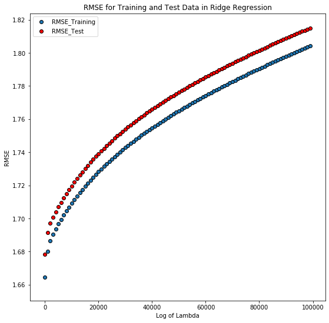

```python
#We are plotting RMSE of train and test for alpha
plt.figure(figsize=(9,9))
plt.scatter(alpha_list, RMSE_train_list, edgecolor='k', label='RMSE_Training')

plt.scatter(alpha_list, RMSE_test_list, c='r', edgecolor='k', label='RMSE_Test')
plt.title('RMSE for Training and Test Data in Ridge Regression')
plt.xlabel('Log of Lambda')
plt.ylabel('RMSE')
plt.legend()
```

*Q5.8-and repeat with Lasso regression again playing a little with different alphas.*

```python
from sklearn.linear_model import Lasso

#We are makinga list of alpha having numbers from 1 to 10000 at intervals of 500.
alpha_list = np.arange(1,100000,1000)
RMSE_train_list = [] #creating an empty list to hold RMSE on training data
RMSE_test_list = [] #creating an empty list to hold RMSE on test data

for alpha_val in alpha_list:

    clf = Lasso(alpha= alpha_val)


    clf.fit(X_train,y_train)

    #RMSE for training data
    y_pred_train = clf.predict(X_train)
    rmse_train= np.sqrt(metrics.mean_squared_error(y_train, y_pred_train))
    RMSE_train_list.append(rmse_train)

    #RMSE for test data
    y_pred_test = clf.predict(X_test)
    rmse_test= np.sqrt(metrics.mean_squared_error(y_test, y_pred_test))
    RMSE_test_list.append(rmse_test)
```

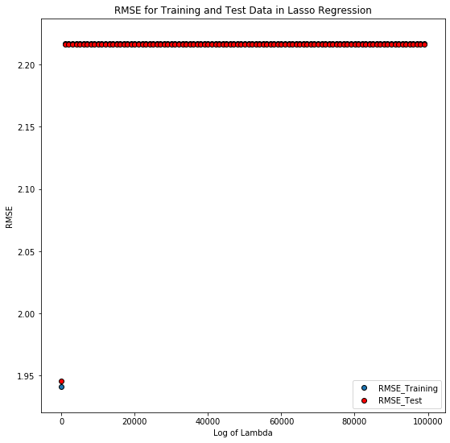

```python
#We are plotting RMSE of train and test for alpha
plt.figure(figsize=(9,9))
plt.scatter(alpha_list, RMSE_train_list, edgecolor='k', label='RMSE_Training')

plt.scatter(alpha_list, RMSE_test_list, c='r', edgecolor='k', label='RMSE_Test')
plt.title('RMSE for Training and Test Data in Lasso Regression')
plt.xlabel('Log of Lambda')
plt.ylabel('RMSE')
plt.legend()
```

```python
#Comparing Ridge and Lasso for test data
alpha_list = np.arange(1,100000,1000)
RMSE_test_list_ridge = []
RMSE_test_list_lasso = []

for alpha_val in alpha_list:
    clf_ridge = Ridge(alpha= alpha_val)
    clf_ridge.fit(X_train,y_train)
    y_pred_test_ridge = clf_ridge.predict(X_test)
    rmse_test_ridge = np.sqrt(metrics.mean_squared_error(y_test, y_pred_test_ridge))
    RMSE_test_list_ridge.append(rmse_test_ridge)

    clf_lasso = Lasso(alpha= alpha_val)
    clf_lasso.fit(X_train,y_train)
    y_pred_test_lasso = clf_lasso.predict(X_test)
    rmse_test_lasso = np.sqrt(metrics.mean_squared_error(y_test, y_pred_test_lasso))
    RMSE_test_list_lasso.append(rmse_test_lasso)
```

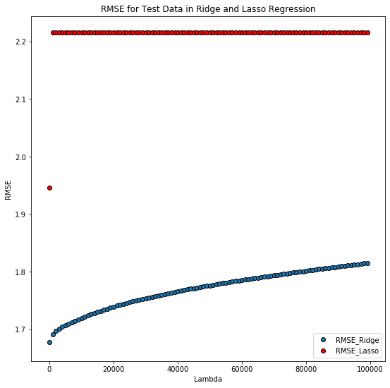

```python
#We are plotting RMSE of train and test for alpha
plt.figure(figsize=(9,9))
plt.scatter(alpha_list, RMSE_test_list_ridge, edgecolor='k', label='RMSE_Ridge')

plt.scatter(alpha_list, RMSE_test_list_lasso, c='r', edgecolor='k', label='RMSE_Lasso')
plt.title('RMSE for Test Data in Ridge and Lasso Regression')
plt.xlabel('Lambda')
plt.ylabel('RMSE')
plt.legend()
```

*Q5.9.a-9. compare RMSE on testing/training data. What does this suggest in terms of overfitting?*

*Q5.9.b-compare RMSE for OLS, Ridge and Lasso*

*Q5.9.c- compare the resulting RMSE with the small benchmark model you did above*

**Q6- Let's Overfit! As WVS is a relatively large dataset we cannot easily over t by adding more variables. But we can go another easy route instead: we take a subsample.**

*Q6.1- Create a subsample of your design matrix and the outcome variable. Choose a large-ish sample that overfits. The size depends on which variables do you exactly choose, in my case 2000 obs rarely overfits (it depends on the train-validation split), 1000 typically overfits.*

Design_Matrix_plusY has the Design matrix and the Y(V23) column. we would select random 1000 rows from this dataframe and seperate the X and Y.

```python
sample_df = Design_Matrix_plusY.sample(n = 1000)
```

```python
sample_Design_Matrix = sample_df.loc[:,sample_df.columns != 'V23']
```

```python
sample_Y = pd.DataFrame(sample_df['V23'])
```

*Q6.2-repeat the steps you did above.*

We would divide into training and test set. we would find condition number of design matrix. We would also find the RMSE for OLS, ridge and Lasso regression models.

```python
X_sample_train, X_sample_test, y_sample_train, y_sample_test = train_test_split(sample_Design_Matrix, sample_Y, test_size=0.2)
```

```python
np.linalg.cond(sample_Design_Matrix)
```

```
8369.60129728666
```

Simple Linear Regression also utilises Ordinary Least Square(OLS) algorithm, so we would scikit learn linear regression library.

```python
#We are doing Linear regression for training data
regressor = LinearRegression()
regressor.fit(X_sample_train, y_sample_train)
y_pred_train = regressor.predict(X_sample_train)
rmse_train= np.sqrt(metrics.mean_squared_error(y_sample_train, y_pred_train))
rmse_train
```

```
1.3616823446011315
```

```python
#We are doing Linear regression for test data
y_pred_test = regressor.predict(X_sample_test)
rmse_test= np.sqrt(metrics.mean_squared_error(y_sample_test, y_pred_test))
rmse_test
```

```
2.090431713160781
```

We would not do Ridge Regression

```python
from sklearn.linear_model import Ridge

#We are makinga list of alpha having numbers from 1 to 10000 at intervals of 500.
alpha_list = np.arange(1,10000,100)
RMSE_train_list = [] #creating an empty list to hold RMSE on training data
RMSE_test_list = [] #creating an empty list to hold RMSE on test data

for alpha_val in alpha_list:

    clf = Ridge(alpha= alpha_val)


    clf.fit(X_sample_train,y_sample_train)

    #RMSE for training data
    y_pred_train = clf.predict(X_sample_train)
    rmse_train= np.sqrt(metrics.mean_squared_error(y_sample_train, y_pred_train))
    RMSE_train_list.append(rmse_train)

    #RMSE for test data
    y_pred_test = clf.predict(X_sample_test)
    rmse_test= np.sqrt(metrics.mean_squared_error(y_sample_test, y_pred_test))
    RMSE_test_list.append(rmse_test)
```

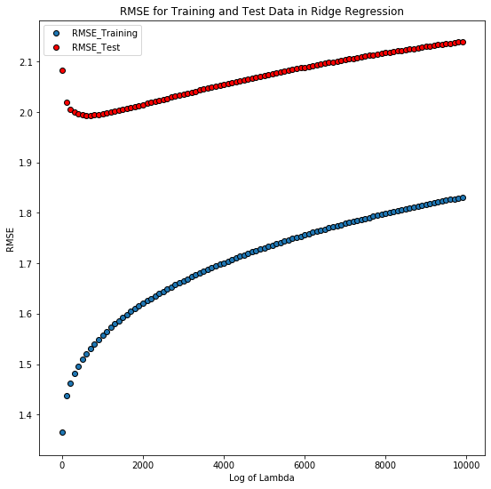

```python
#We are plotting RMSE of train and test for alpha
plt.figure(figsize=(9,9))
plt.scatter(alpha_list, RMSE_train_list, edgecolor='k', label='RMSE_Training')

plt.scatter(alpha_list, RMSE_test_list, c='r', edgecolor='k', label='RMSE_Test')
plt.title('RMSE for Training and Test Data in Ridge Regression')
plt.xlabel('Log of Lambda')
plt.ylabel('RMSE')
plt.legend()
```

We would now do for Lasso.

```python
from sklearn.linear_model import Lasso

#We are makinga list of alpha having numbers from 1 to 10000 at intervals of 500.
alpha_list = np.arange(1,10000,100)
RMSE_train_list = [] #creating an empty list to hold RMSE on training data
RMSE_test_list = [] #creating an empty list to hold RMSE on test data

for alpha_val in alpha_list:

    clf = Lasso(alpha= alpha_val)


    clf.fit(X_sample_train,y_sample_train)

    #RMSE for training data
    y_pred_train = clf.predict(X_sample_train)
    rmse_train= np.sqrt(metrics.mean_squared_error(y_sample_train, y_pred_train))
    RMSE_train_list.append(rmse_train)

    #RMSE for test data
    y_pred_test = clf.predict(X_sample_test)
    rmse_test= np.sqrt(metrics.mean_squared_error(y_sample_test, y_pred_test))
    RMSE_test_list.append(rmse_test)
```

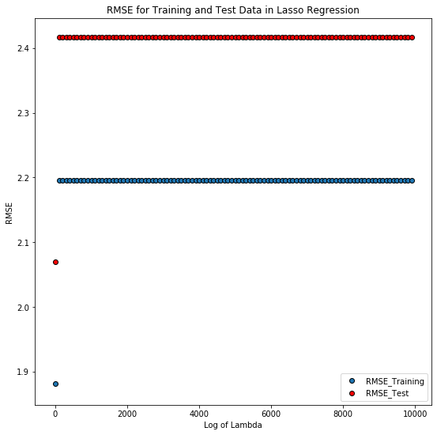

```python
#We are plotting RMSE of train and test for alpha
plt.figure(figsize=(9,9))
plt.scatter(alpha_list, RMSE_train_list, edgecolor='k', label='RMSE_Training')

plt.scatter(alpha_list, RMSE_test_list, c='r', edgecolor='k', label='RMSE_Test')
plt.title('RMSE for Training and Test Data in Lasso Regression')
plt.xlabel('Log of Lambda')
plt.ylabel('RMSE')
plt.legend()
```

*Q6.3-comment how do OLS, Ridge, Lasso perform on testing/training in case of overfitting.*

In the case of OLS, Ridge and Lasso the RMSE_test was quite higher than RMSE_train which is a clear case of overfitting.

*Q6.4-4. comment the condition number of design matrix and overfitting.*